# Assignment 2, EDDA 2017

Martin de la Riva and Kieran O’Driscoll, group 23

24 April 2017

## Exercise 1

### 1.

For this exercise we first create an exponential distribution of a significant amount of elements with $\lambda = 0.035$. With this, we get a precise value fo what the median of such distribution is.

```r
telephone=read.table("telephone.txt",header=TRUE)

# exponential distribution of 20000 elements
exp_d = rexp(20000, rate=0.035)
exp_d_median = median(exp_d)
```

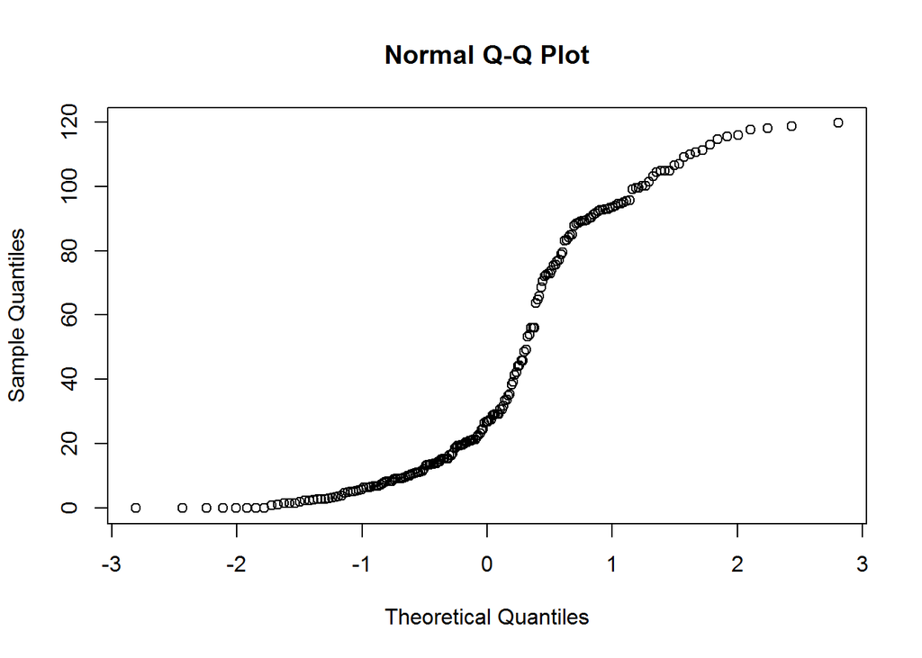

```r
# Test if data may come from a Symmetric population
qqnorm(telephone[,"Bills"])
```

```r
# Rejected, median is not close to exponential median
wilcox.test(telephone[,"Bills"], mu = exp_d_median)
```

```
##
##  Wilcoxon signed rank test with continuity correction
##
## data:  telephone[, "Bills"]
## V = 14600, p-value = 2.837e-08
## alternative hypothesis: true location is not equal to 19.66075
```

This results in a really low p-value, therefore rejecting the hypothesis that the data stems from an exponential distribution with rate $\lambda = 0.035$.

### 2.

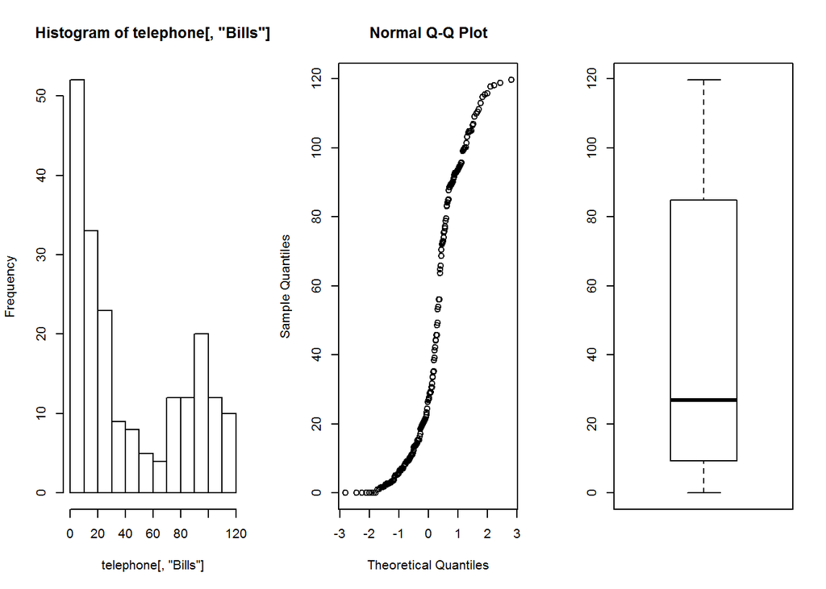

```r
par(mfrow=c(1,3))
hist(telephone[,"Bills"])
qqnorm(telephone[,"Bills"])
boxplot(telephone[,"Bills"])
```

In Conclusion:  
Either offer a cheap service of less than 30$; or create a high quality service with a price lower than 80$, so you win clients that are used to pay more.

## Exercise 2

Firstly, we have different measures in the datasets. We need to transform these values in order to have the 3 datasets with the same measures and criteria.  
We will use the 1879-1882 criteria, which is in km/s, and subustracting 299000 to it. In order to do this we will have to transform light3 into this criteria. We know light3 was calculated measuring how many microseconds it takes to perform 7442 km, and afterwards substracting 24.8 milliseconds.

NOTE: We assumed the assignment means milliseconds when talking about Newcomb measurements (24.8 substracted), as after multiplying by 1000 you do get microseconds, and otherways the measurements don’t match by any means the speed of light.

```r
light1 = scan("light1879.txt")
light2 = scan("light1882.txt")
light3 = scan("light.txt")

# Transform light3 to 1879-1882 criteria
light3 = (light3/1000)+24.8 # milliseconds
light3 = (light3/1000) # seconds to perform 7442 km
light3 = (7442/light3) # in 1 second it will perform x km (transform to km/s)
light3 = light3 - 299000 # final 1879-1882 criteria
```

### 1.

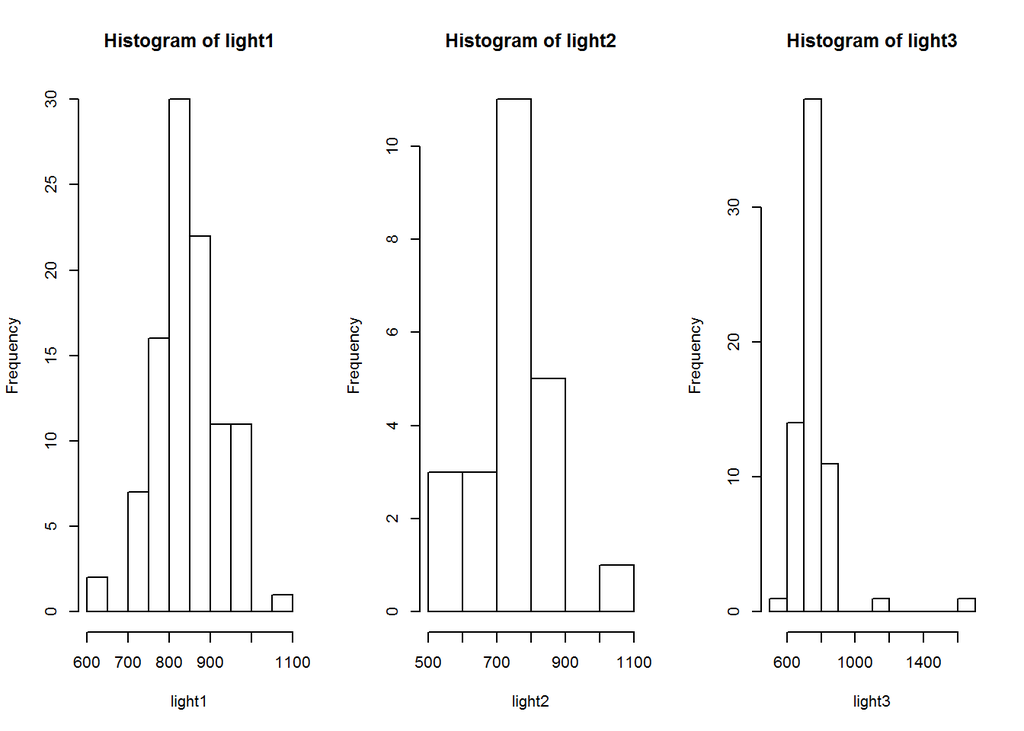

```r
par(mfrow=c(1,3))
hist(light1)
hist(light2)
hist(light3)
```

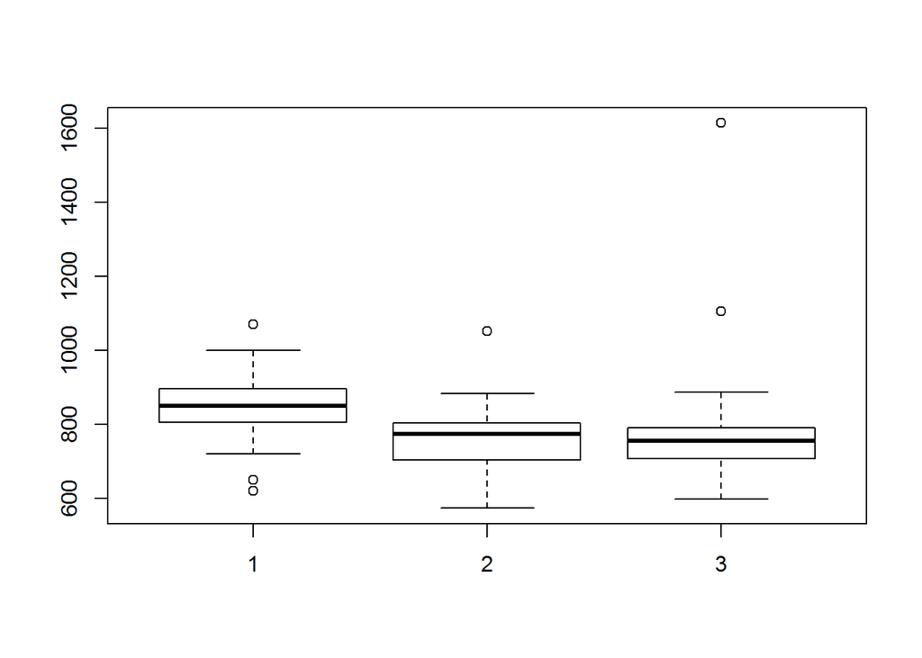

```r
par(mfrow=c(1,1))
boxplot(light1, light2, light3)
```

Michelson second experiment coincides with Newcomb measurements, while Michelson’s first experiment (light1) differs from them others.  
Although histograms weren’t as helpful as we expected them to be, the Boxplots were really useful to see the similarities and differences between the datasets.

### 2.

```r
t.test(light1)$conf.int
```

```
## [1] 836.7226 868.0774
## attr(,"conf.level")
## [1] 0.95
```

```r
t.test(light2)$conf.int
```

```
## [1] 709.8976 802.5372
## attr(,"conf.level")
## [1] 0.95
```

```r
t.test(light3)$conf.int
```

```
## [1] 731.9112 795.8250
## attr(,"conf.level")
## [1] 0.95
```

NOTE: We maintained 1879-1882 criteria (km/sec - 299000). We also tried with only km/sec, but the confidence intervals where exactly the same although adding 299000 to them.

### 3.

Again, 2 and 3 coincide (light3 interval is inside light2 confidence interval values), while 1 differs, having a confidence interval with higher values, and being completely outside of the two other ones.

### 4.

```r
most_precise_speed_of_light = 299792.458 - 299000
most_precise_speed_of_light
```

```
## [1] 792.458
```

shows that Michelson’s first experiment measures were clearly off, while his second and Newcomb’s were much closer to the current accepted solution.

## Exercise 3

### 1.

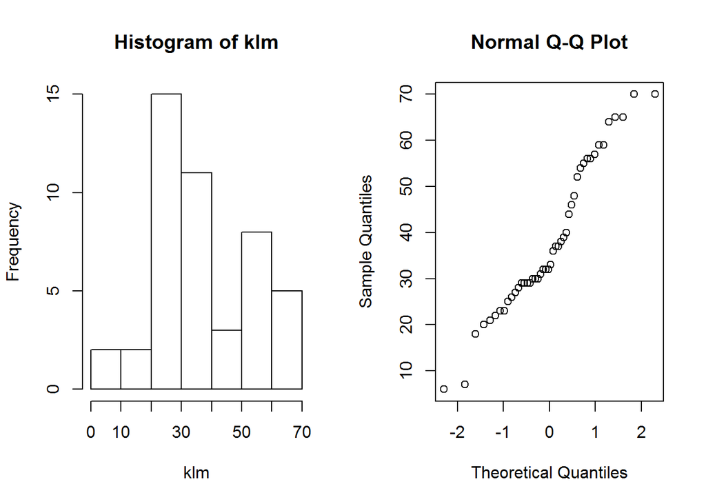

```r
klm = scan("klm.txt")
# First, we check distribution of the data.
klm <- klm[klm<71]
par(mfrow=c(1,2))
hist(klm)
qqnorm(klm)
```

Assuming the maximum delivery duration of the parts is 70 days, we first ignore outliers that are out of that assumption.  
In order to test the median we can know two methods, a sign test or a Wilcoxon test. Looking at the histogram and QQ-plot, we can assume the data to stem from a symmetric population with a certain median. Therefore, we can use Wilcoxon test, which is preferred as it is based on more information about the dataset.  
In order to test wether the median is 32 or less, we will firstly test if it’s equal to 32, and if it is rejected check lower values to see if it can have a lower median.

```r
wilcox.test(klm,mu=32)
```

```
##
##  Wilcoxon signed rank test with continuity correction
##
## data:  klm
## V = 638.5, p-value = 0.04627
## alternative hypothesis: true location is not equal to 32
```

We get a low p-value, and therefore the hypothesis that the median is equal to 32 is rejected. When testing lower values, it can be seen how the p-value decreases, and therefore we also reject the hypothesis that the median of the population may be lower than 32.

```r
wilcox.test(klm,mu=31)[[3]]
```

```
## [1] 0.02354406
```

```r
wilcox.test(klm,mu=30)[[3]]
```

```
## [1] 0.004790985
```

### 2.

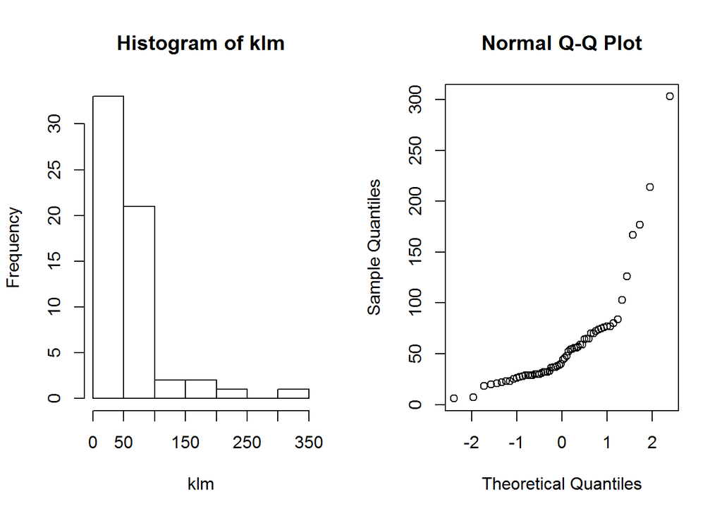

```r
klm = scan("klm.txt")
par(mfrow=c(1,2))
hist(klm)
qqnorm(klm)
```

As it can be seen in the plots, in this case we cannot make the symmetric assumption, and therefore we have to perform a sign Binomial test.

```r
binom.test(sum(klm>70),sum(!!klm),p=0.1)
```

```
##
##  Exact binomial test
##
## data:  sum(klm > 70) and sum(!(!klm))
## number of successes = 14, number of trials = 60, p-value =
## 0.002028
## alternative hypothesis: true probability of success is not equal to 0.1
## 95 percent confidence interval:
##  0.1338373 0.3603828
## sample estimates:
## probability of success
##              0.2333333
```

The test returns a confidence interval between 13.38% and 36.04%, and therefore KLM criterion (at most 10% of parts take more than 70 days) is not met.

## Exercise 4